# DSC_1105_FA1

Frances Aneth Rosales

2024-02-16

# Read & Show Data

```r
library(readr)
filepath <- read_csv("cytof_one_experiment.csv")
filepath
```

```
## # A tibble: 50,000 × 35
##     NKp30 KIR3DL1  NKp44 KIR2DL1 GranzymeB   CXCR6  CD161 KIR2DS4 NKp46   NKG2D
##     <dbl>   <dbl>  <dbl>   <dbl>     <dbl>   <dbl>  <dbl>   <dbl> <dbl>   <dbl>
##  1  0.188  3.62   -0.561  -0.294     2.48  -0.145  -0.315  1.94   4.08   2.62
##  2  1.03   1.70   -0.289  -0.480     3.26  -0.0339 -0.411  3.80   3.73  -0.483
##  3  3.00   6.14    1.90    0.482     4.28   1.95   -0.502 -0.320  4.56  -0.507
##  4  4.30  -0.221   0.243  -0.483     3.35   0.926   3.88  -0.170  4.48   1.93
##  5 -0.439 -0.504  -0.153   0.751     3.19  -0.0589  1.09  -0.0503 0.838 -0.458
##  6  2.09  -0.399   3.46   -0.520     4.35  -0.364  -0.571 -0.450  4.06   3.43
##  7 -0.613 -0.117  -0.451   3.55      1.54  -0.414   0.725 -0.0674 2.67  -0.0838
##  8 -0.341 -0.253  -0.459   2.90     -0.545 -0.612  -0.128  2.79   0.726  2.10
##  9  2.31  -0.364  -0.573   3.84      2.92   2.46    2.25  -0.376  4.33  -0.0168
## 10  3.48  -0.0282 -0.182   4.20      4.74   0.695   5.08   4.19   4.54   2.16
## # … with 49,990 more rows, and 25 more variables: NKG2C <dbl>, X2B4 <dbl>,
## #   CD69 <dbl>, KIR3DL1.S1 <dbl>, CD2 <dbl>, KIR2DL5 <dbl>, DNAM.1 <dbl>,
## #   CD4 <dbl>, CD8 <dbl>, CD57 <dbl>, TRAIL <dbl>, KIR3DL2 <dbl>, MIP1b <dbl>,
## #   CD107a <dbl>, GM.CSF <dbl>, CD16 <dbl>, TNFa <dbl>, ILT2 <dbl>,
## #   Perforin <dbl>, KIR2DL2.L3.S2 <dbl>, KIR2DL3 <dbl>, NKG2A <dbl>,
## #   NTB.A <dbl>, CD56 <dbl>, INFg <dbl>
```

```r
head(filepath)
```

```
## # A tibble: 6 × 35
##    NKp30 KIR3DL1  NKp44 KIR2DL1 GranzymeB   CXCR6  CD161 KIR2DS4 NKp46  NKG2D
##    <dbl>   <dbl>  <dbl>   <dbl>     <dbl>   <dbl>  <dbl>   <dbl> <dbl>  <dbl>
## 1  0.188   3.62  -0.561  -0.294      2.48 -0.145  -0.315  1.94   4.08   2.62
## 2  1.03    1.70  -0.289  -0.480      3.26 -0.0339 -0.411  3.80   3.73  -0.483
## 3  3.00    6.14   1.90    0.482      4.28  1.95   -0.502 -0.320  4.56  -0.507
## 4  4.30   -0.221  0.243  -0.483      3.35  0.926   3.88  -0.170  4.48   1.93
## 5 -0.439  -0.504 -0.153   0.751      3.19 -0.0589  1.09  -0.0503 0.838 -0.458
## 6  2.09   -0.399  3.46   -0.520      4.35 -0.364  -0.571 -0.450  4.06   3.43
## # … with 25 more variables: NKG2C <dbl>, X2B4 <dbl>, CD69 <dbl>,
## #   KIR3DL1.S1 <dbl>, CD2 <dbl>, KIR2DL5 <dbl>, DNAM.1 <dbl>, CD4 <dbl>,
## #   CD8 <dbl>, CD57 <dbl>, TRAIL <dbl>, KIR3DL2 <dbl>, MIP1b <dbl>,
## #   CD107a <dbl>, GM.CSF <dbl>, CD16 <dbl>, TNFa <dbl>, ILT2 <dbl>,
## #   Perforin <dbl>, KIR2DL2.L3.S2 <dbl>, KIR2DL3 <dbl>, NKG2A <dbl>,
## #   NTB.A <dbl>, CD56 <dbl>, INFg <dbl>
```

# INTERPRET THE DATA

**Upon analyzing the plotting, we have found that the mean of the data is indicated by the mean value of 3.457494 for the “GranzymeB” column. The density map indicates a peak in density within this range of values around 4 . The finding derived from the mean calculation is supported by this concentration, which suggests that a sizable fraction of the “GranzymeB” values cluster around the mean. Furthermore, the density plot’s variability indicates that there is spread in the data, showing a range of values, even if the central tendency is around 4. All things considered, this interpretation offers a thorough understanding of the “GranzymeB” value distribution, with a noticeable emphasis on the mean.**

```r
mean(filepath$GranzymeB)
```

```
## [1] 3.457494
```

Click to Hide/Show Plots

# Histogram

**to show the histogram of our desired column “GranzymeB”.**

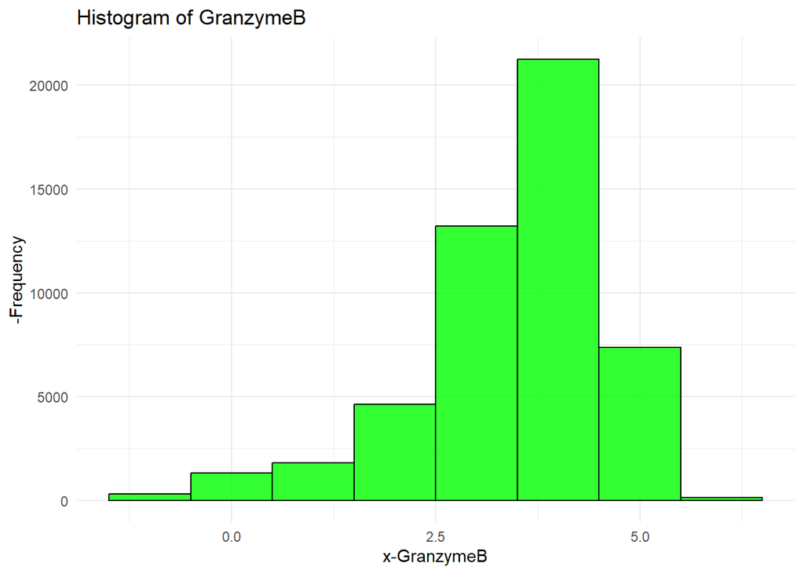

```r
library(ggplot2)

ggplot(filepath, aes(x = GranzymeB)) +
  geom_histogram(binwidth = 1, fill = "green", color = "black", alpha = 0.8) +
  labs(title = "Histogram of GranzymeB",
       x = "x-GranzymeB",
       y = "-Frequency") +
  theme_minimal()
```

# Density Estimates

**We can also utilize Density Plotting to analyze the plot of GranzymeB.**

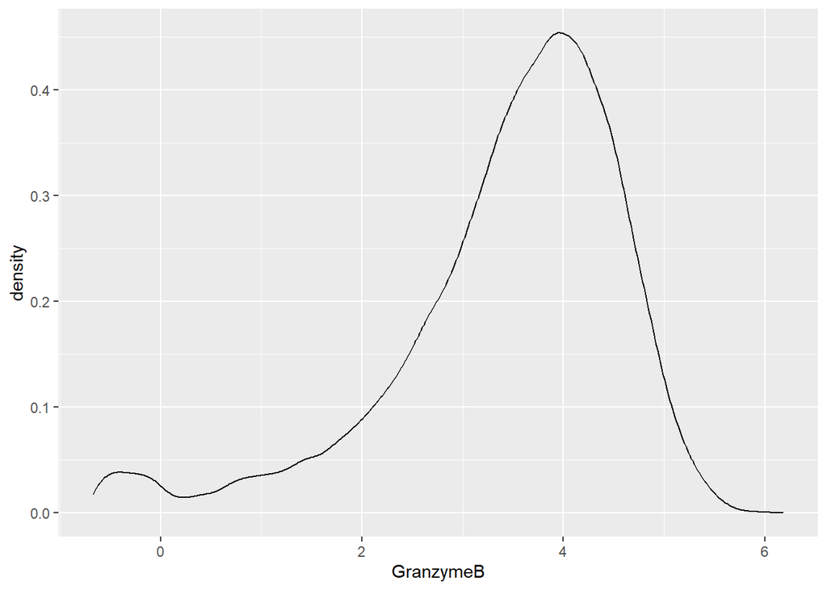

```r
library(ggplot2)

ggplot(filepath, aes(x = GranzymeB)) + geom_density()
```

# Quantile Plot of GranzymeB

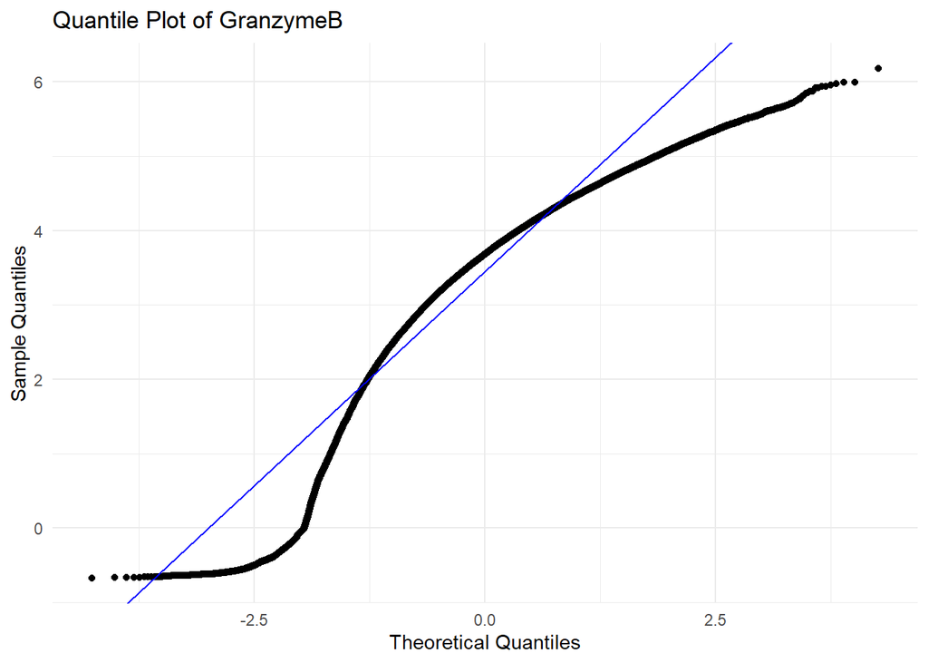

```r
library(ggplot2)

ggplot(filepath, aes(sample = GranzymeB)) +
  stat_qq() +
  geom_abline(intercept = mean(filepath$GranzymeB), slope = sd(filepath$GranzymeB), color = "blue") +
  labs(title = "Quantile Plot of GranzymeB",
       x = "Theoretical Quantiles",
       y = "Sample Quantiles") +
  theme_minimal()
```

# Checking other columns to analyze

```r
print(colnames(filepath))
```

```
##  [1] "NKp30"         "KIR3DL1"       "NKp44"         "KIR2DL1"
##  [5] "GranzymeB"     "CXCR6"         "CD161"         "KIR2DS4"
##  [9] "NKp46"         "NKG2D"         "NKG2C"         "X2B4"
## [13] "CD69"          "KIR3DL1.S1"    "CD2"           "KIR2DL5"
## [17] "DNAM.1"        "CD4"           "CD8"           "CD57"
## [21] "TRAIL"         "KIR3DL2"       "MIP1b"         "CD107a"
## [25] "GM.CSF"        "CD16"          "TNFa"          "ILT2"
## [29] "Perforin"      "KIR2DL2.L3.S2" "KIR2DL3"       "NKG2A"
## [33] "NTB.A"         "CD56"          "INFg"
```

# INTERPRET THE DATA

Click to Hide/Show Plots

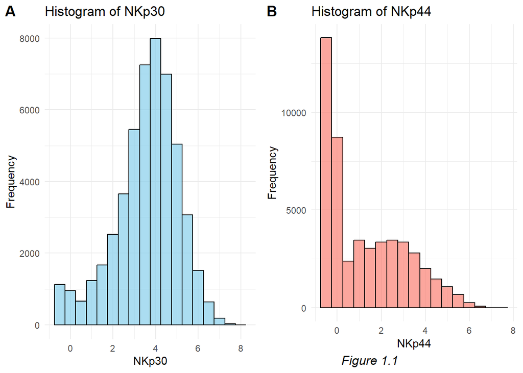

```r
library(ggplot2)

hist_NKp30 <- ggplot(filepath, aes(x = NKp30)) +
  geom_histogram(binwidth = 0.5, fill = "skyblue", color = "black", alpha = 0.7) +
  labs(title = "Histogram of NKp30",
       x = "NKp30",
       y = "Frequency") +
  theme_minimal()

hist_NKp44 <- ggplot(filepath, aes(x = NKp44)) +
  geom_histogram(binwidth = 0.5, fill = "salmon", color = "black", alpha = 0.7) +
  labs(title = "Histogram of NKp44",
       x = "NKp44",
       y = "Frequency", caption = "Figure 1.1") +
  theme_minimal() +
  theme(plot.caption = element_text(hjust = .2, size = 12, face = "italic"))


combined_plot <- cowplot::plot_grid(hist_NKp30, hist_NKp44, labels = c("A", "B"))

combined_plot
```

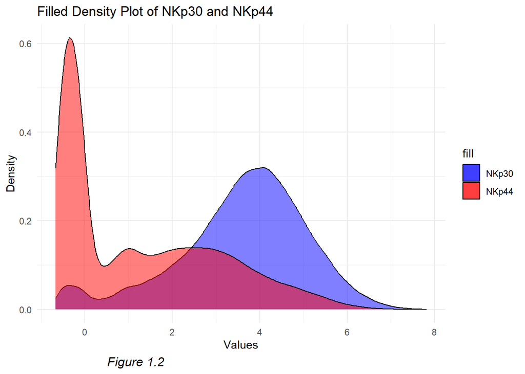

```r
ggplot(filepath, aes(x = NKp30, fill = "NKp30")) +
  geom_density(alpha = 0.5) +
  geom_density(aes(x = NKp44, fill = "NKp44"), alpha = 0.5) +
  labs(title = "Filled Density Plot of NKp30 and NKp44",
       x = "Values",
       y = "Density", caption = "Figure 1.2") +
  scale_fill_manual(values = c("NKp30" = "blue", "NKp44" = "red")) +
  theme_minimal()  +
  theme(plot.caption = element_text(hjust = .2, size = 12, face = "italic"))
```